# LAB4 EXPLORATORY DATA ANALYSIS - EDA

### Nội dung thực hành

Đọc paper, khảo sát bài toán liên quan Phân tích khám phá dữ liệu

- Xác định tính chất
- Phân tích đơn biến
- Phân tích đa biến
- Xác định giá trị thiếu, và mẫu bất thường
- Xác định ngoại lệ

### Bài làm

#### Import thư viện

```python
import numpy as np
import pandas as pd
import matplotlib.pyplot as plt
import seaborn as sns
sns.set_style('whitegrid')
%matplotlib inline
```

#### Đọc dữ liệu và gán column names

```python
column_names = [ 'Pregnancies', 'Glucose', 'BloodPressure', 'SkinThickness',
        'Insulin', 'BMI', 'DiabetesPedigreeFunction', 'Age', 'Outcome']
df=pd.read_csv('pima-indians-diabetes.csv', header=None, names=column_names)
df.head()
```

|  | Pregnancies | Glucose | BloodPressure | SkinThickness | Insulin | BMI | DiabetesPedigreeFunction | Age | Outcome |
| --- | --- | --- | --- | --- | --- | --- | --- | --- | --- |
| 0 | 6 | 148 | 72 | 35 | 0 | 33.6 | 0.627 | 50 | 1 |
| 1 | 1 | 85 | 66 | 29 | 0 | 26.6 | 0.351 | 31 | 0 |
| 2 | 8 | 183 | 64 | 0 | 0 | 23.3 | 0.672 | 32 | 1 |
| 3 | 1 | 89 | 66 | 23 | 94 | 28.1 | 0.167 | 21 | 0 |
| 4 | 0 | 137 | 40 | 35 | 168 | 43.1 | 2.288 | 33 | 1 |

```python
df.columns
```

```
Index(['Pregnancies', 'Glucose', 'BloodPressure', 'SkinThickness', 'Insulin',
       'BMI', 'DiabetesPedigreeFunction', 'Age', 'Outcome'],
      dtype='object')
```

#### Check data

##### Tổng quan dữ liệu

```python
df.info()
```

```
<class 'pandas.core.frame.DataFrame'>
RangeIndex: 768 entries, 0 to 767
Data columns (total 9 columns):
 #   Column                    Non-Null Count  Dtype
---  ------                    --------------  -----
 0   Pregnancies               768 non-null    int64
 1   Glucose                   768 non-null    int64
 2   BloodPressure             768 non-null    int64
 3   SkinThickness             768 non-null    int64
 4   Insulin                   768 non-null    int64
 5   BMI                       768 non-null    float64
 6   DiabetesPedigreeFunction  768 non-null    float64
 7   Age                       768 non-null    int64
 8   Outcome                   768 non-null    int64
dtypes: float64(2), int64(7)
memory usage: 54.1 KB
```

##### Thống kê dữ liệu

```python
df.describe()
```

|  | Pregnancies | Glucose | BloodPressure | SkinThickness | Insulin | BMI | DiabetesPedigreeFunction | Age | Outcome |
| --- | --- | --- | --- | --- | --- | --- | --- | --- | --- |
| count | 768.000000 | 768.000000 | 768.000000 | 768.000000 | 768.000000 | 768.000000 | 768.000000 | 768.000000 | 768.000000 |
| mean | 3.845052 | 120.894531 | 69.105469 | 20.536458 | 79.799479 | 31.992578 | 0.471876 | 33.240885 | 0.348958 |
| std | 3.369578 | 31.972618 | 19.355807 | 15.952218 | 115.244002 | 7.884160 | 0.331329 | 11.760232 | 0.476951 |
| min | 0.000000 | 0.000000 | 0.000000 | 0.000000 | 0.000000 | 0.000000 | 0.078000 | 21.000000 | 0.000000 |
| 25% | 1.000000 | 99.000000 | 62.000000 | 0.000000 | 0.000000 | 27.300000 | 0.243750 | 24.000000 | 0.000000 |
| 50% | 3.000000 | 117.000000 | 72.000000 | 23.000000 | 30.500000 | 32.000000 | 0.372500 | 29.000000 | 0.000000 |
| 75% | 6.000000 | 140.250000 | 80.000000 | 32.000000 | 127.250000 | 36.600000 | 0.626250 | 41.000000 | 1.000000 |
| max | 17.000000 | 199.000000 | 122.000000 | 99.000000 | 846.000000 | 67.100000 | 2.420000 | 81.000000 | 1.000000 |

Nhận xét :

- Pregnancies min=0 tức là chưa mang thai lần nào dữ liệu hợp lệ
- Glucose min=0 => Bất hợp lí
- BloodPressure min=0 => Huyết áp =0 bất hợp lí
- SkinThickness,BMI, Insulin tương tự => Bất hợp lí

##### => Data bị thiếu hoặc không có dữ liệu ghi nhân cần xử lý phần bất hợp lí

### Làm sạch dữ liệu

##### Xử lý giá trị =0

```python
import numpy as np
columns_zero = ['Glucose','BloodPressure','SkinThickness','Insulin','BMI']
# Chuyển cột về float để có thể chứa NaN, sau đó thay thế 0 -> NaN
df[columns_zero] = df[columns_zero].astype(float).replace(0, np.nan)
# Điền NaN bằng giá trị trung bình của từng cột
df[columns_zero] = df[columns_zero].fillna(df[columns_zero].mean())
print("\n-- Kiểm tra lại số lượng giá trị thiếu sau khi xử lý: ---")
print(df.isnull().sum())
print("\n-- Thống kê mô tả sau khi làm sạch dữ liệu: ---")
print(df.describe())
```

```
-- Kiểm tra lại số lượng giá trị thiếu sau khi xử lý: ---
Pregnancies                 0
Glucose                     0
BloodPressure               0
SkinThickness               0
Insulin                     0
BMI                         0
DiabetesPedigreeFunction    0
Age                         0
Outcome                     0
dtype: int64

-- Thống kê mô tả sau khi làm sạch dữ liệu: ---
       Pregnancies     Glucose  BloodPressure  SkinThickness     Insulin  \
count   768.000000  768.000000     768.000000     768.000000  768.000000
mean      3.845052  121.686763      72.405184      29.153420  155.548223
std       3.369578   30.435949      12.096346       8.790942   85.021108
min       0.000000   44.000000      24.000000       7.000000   14.000000
25%       1.000000   99.750000      64.000000      25.000000  121.500000
50%       3.000000  117.000000      72.202592      29.153420  155.548223
75%       6.000000  140.250000      80.000000      32.000000  155.548223
max      17.000000  199.000000     122.000000      99.000000  846.000000

              BMI  DiabetesPedigreeFunction         Age     Outcome
count  768.000000                768.000000  768.000000  768.000000
mean    32.457464                  0.471876   33.240885    0.348958
std      6.875151                  0.331329   11.760232    0.476951
min     18.200000                  0.078000   21.000000    0.000000
25%     27.500000                  0.243750   24.000000    0.000000
50%     32.400000                  0.372500   29.000000    0.000000
75%     36.600000                  0.626250   41.000000    1.000000
max     67.100000                  2.420000   81.000000    1.000000
```

#### Nhận xét :

- Các giá trị 0 bất hợp lý đ thay thế bằng giá trị trung bình (`mean`) của mỗi cột.
- Dữ liệu hiện tại đã không còn giá trị `NaN`. Chúng ta có thể bắt đầu trực quan hóa.

### Trực quan hóa dữ liệu

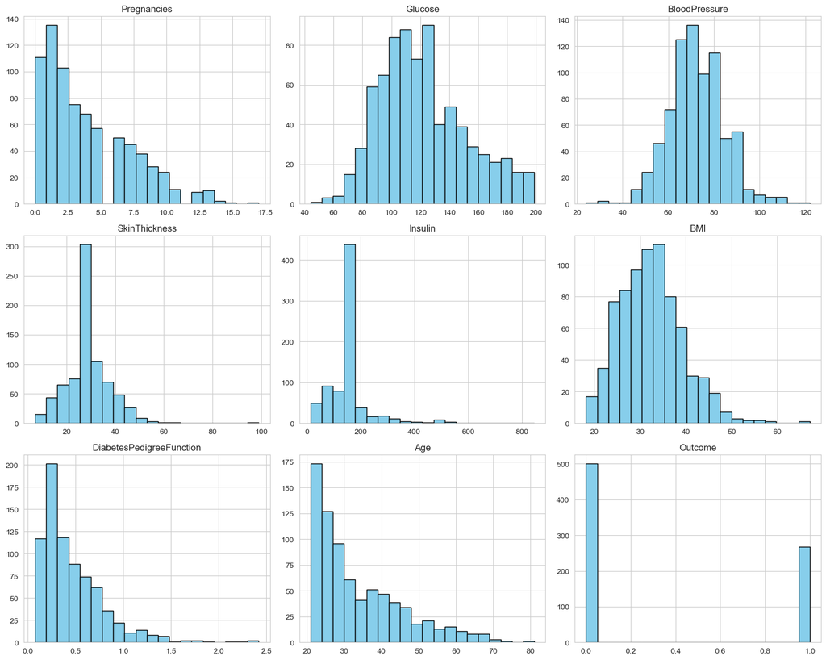

```python
df.hist(figsize=(15,12),bins=20, color='skyblue',edgecolor='black')
plt.tight_layout()
plt.show()
```

#### Nhận xét về phân phối các biến:

```python
# Kiểm tra độ lệch (skewness) để xác nhận nhận xét từ histogram
print("===== Độ lệch của các biến =====")
print(df.skew(numeric_only=True))
```

```
===== Độ lệch của các biến =====
Pregnancies                 0.901674
Glucose                     0.532719
BloodPressure               0.137305
SkinThickness               0.822173
Insulin                     3.019084
BMI                         0.598253
DiabetesPedigreeFunction    1.919911
Age                         1.129597
Outcome                     0.635017
dtype: float64
```

#### Nhận xét :

- Kết luận :
  - `Insulin` (3.01) và `DiabetesPedigreeFunction` (1.91) có độ lệch phải.
  - `Age` (1.12), `Pregnancies` (0.90), `BMI` (0.59) cũng lệch phải.

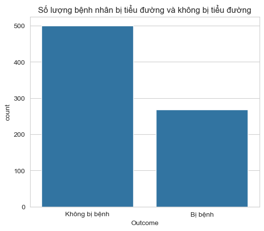

```python
plt.figure(figsize=(6,5))
sns.countplot(x='Outcome',data=df)
plt.title('Số lượng bệnh nhân bị tiểu đường và không bị tiểu đường')
plt.xticks([0,1],['Không bị bệnh','Bị bệnh'])
plt.show()
```

Nhận xét : Số lượng người không bị bệnh nhiều hơn gần gấp đôi bị bệnh => Dữ liệu mất cân bằng

## Phân tích đa biến

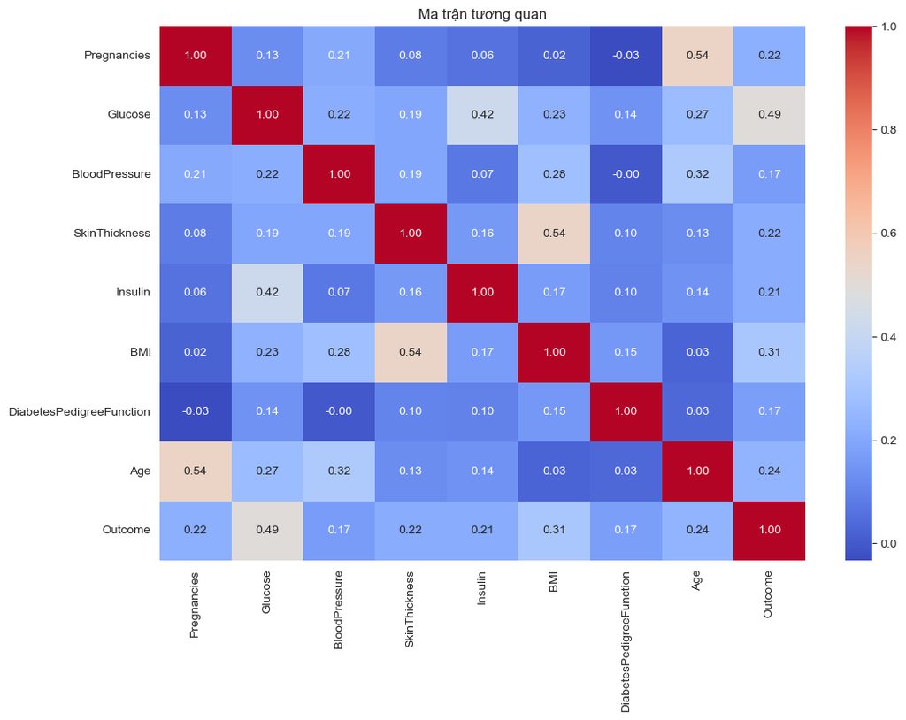

```python
plt.figure(figsize=(12,8))
correlation_matrix=df.corr()
sns.heatmap(correlation_matrix,annot=True, cmap='coolwarm',fmt=".2f")
plt.title('Ma trận tương quan')
plt.show()
```

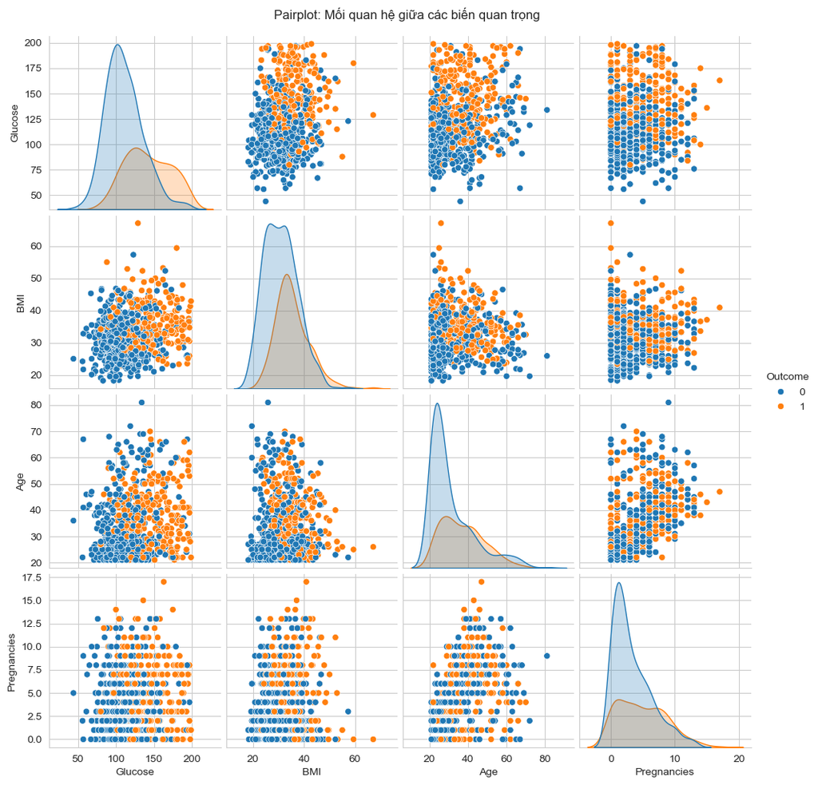

```python
sns.pairplot(df[['Glucose','BMI','Age','Pregnancies','Outcome']], hue="Outcome", diag_kind="kde")
plt.suptitle("Pairplot: Mối quan hệ giữa các biến quan trọng", y=1.02)
plt.show()
```

#### Nhận xét Pairplot:

- **Phân phối (đường chéo):** Phân phối của người bị bệnh (màu cam) thường dịch về phía bên phải (giá trị cao hơn) ở các biến `Glucose`, `BMI`, `Age`, và `Pregnancies`.
- **Scatter plots:**
  - Có thể thấy sự phân tách rõ ràng hơn giữa hai nhóm `Outcome` khi nhìn vào biểu đồ của `Glucose` so với các biến khác.
  - Mối quan hệ giữa `Age` và `Pregnancies` cho thấy một xu hướng tăng chung.

### Phân tích ngoại lệ

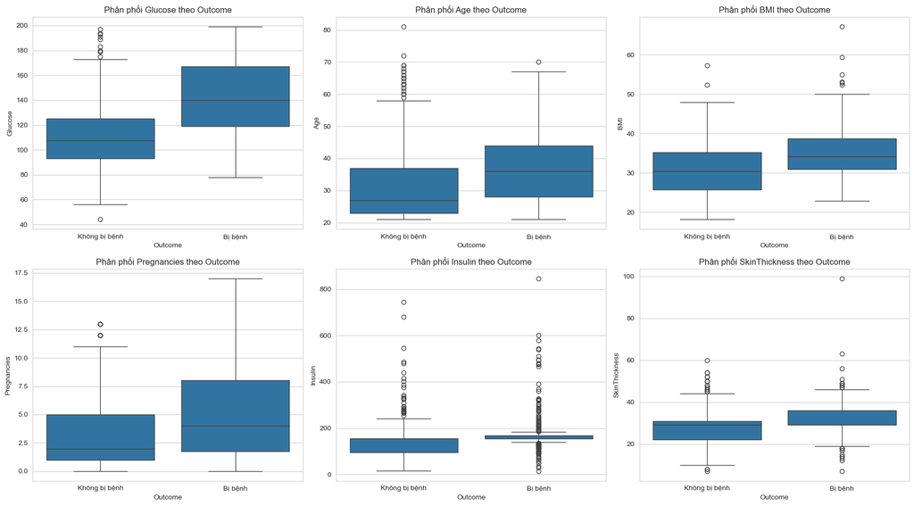

```python
fig, axes = plt.subplots(2, 3, figsize=(18,10))
cols = ['Glucose','Age', 'BMI', 'Pregnancies', 'Insulin', 'SkinThickness']
for ax, col in zip(axes.flatten(), cols):
    sns.boxplot(x='Outcome', y=col, data=df, ax=ax)
    ax.set_title(f'Phân phối {col} theo Outcome')
    ax.set_xticks([0,1])
    ax.set_xticklabels(['Không bị bệnh', 'Bị bệnh'])
plt.tight_layout()
plt.show()
```

#### Nhận xét Phân phối các biến theo Outcome:

- **Glucose:** Nhóm người bị bệnh (Outcome=1) có mức đường huyết trung vị (đường kẻ giữa hộp) cao hơn hẳn so với nhóm không bị bệnh. Sự phân bố của nhóm bị bệnh cũng rộng hơn.
- **BMI & SkinThickness:** Cả hai chỉ số này đều có trung vị cao hơn ở nhóm người bị bệnh. Có nhiều giá trị ngoại lệ (outliers) ở cả hai nhóm, đặc biệt ở SkinThickness.
- **Age & Pregnancies:** Trung vị của tuổi và số lần mang thai ở nhóm bị bệnh đều cao hơn. Điều này cho thấy bệnh tiểu đường phổ biến hơn ở những người lớn tuổi và đã mang thai nhiều lần.
- **Insulin:** Biến này có số lượng lớn các giá trị ngoại lệ, cho thấy sự biến thiên rất lớn trong nồng độ insulin giữa các cá nhân, đặc biệt là ở những người mắc bệnh.
- **Kết luận:** Các biến `Glucose`, `BMI`, và `Age` dường như là những yếu tố dự báo quan trọng cho việc chẩn đoán bệnh tiểu đường.